# Yassin Pellicer Lamla - MIADB 2026/2027

Proyecto de Python para Análisis de Datos

## Inicialización de los dataFrames

```python
import pandas as pd
import numpy as np
import seaborn as sns  # type: ignore
import matplotlib as plt
import matplotlib.pyplot as plt
```

```python
athletes_df = pd.read_csv('atletas.csv')
medals_df = pd.read_csv('medallas.csv')
```

## 1. Relación entre los datos de entrada

### Análisis

1.1. Los dataFrames "atletas" y "medallas" proporcionan la información de las participaciones de cada atleta en los juegos olímpicos. Medallas muestra las participaciones, y Atletas guarda la información de cada atleta participante. Los dataFrames se relacionan con la columna ID, que referencia a cada Atleta con su respectiva participación.

```python
athletes_df.info(); print()
medals_df.info(); print()
```

```
<class 'pandas.DataFrame'>
RangeIndex: 135571 entries, 0 to 135570
Data columns (total 8 columns):
 #   Column  Non-Null Count   Dtype
---  ------  --------------   -----
 0   ID      135571 non-null  int64
 1   Name    135571 non-null  str
 2   Sex     135571 non-null  str
 3   Age     129203 non-null  float64
 4   Height  101655 non-null  float64
 5   Weight  100686 non-null  float64
 6   Team    135571 non-null  str
 7   NOC     135571 non-null  str
dtypes: float64(3), int64(1), str(4)
memory usage: 8.3 MB

<class 'pandas.DataFrame'>
RangeIndex: 271116 entries, 0 to 271115
Data columns (total 8 columns):
 #   Column  Non-Null Count   Dtype
---  ------  --------------   -----
 0   ID      271116 non-null  int64
 1   Games   271116 non-null  str
 2   Year    271116 non-null  int64
 3   Season  271116 non-null  str
 4   City    271116 non-null  str
 5   Sport   271116 non-null  str
 6   Event   271116 non-null  str
 7   Medal   39783 non-null   str
dtypes: int64(2), str(6)
memory usage: 16.5 MB
```

A continuación un listado con nombre del atleta, país, tipo de juegos, años en los que participó y medallas obtenidas en cada año. Para ello se deben agrupar los dos dataFrames por la columna ID. La salida estará ordenada por número de medallas en orden desdendente.

```python
athlete_medals_df = pd.merge(athletes_df, medals_df, on="ID")

listing = (
  athlete_medals_df
  .groupby(["ID", "Name", "NOC", "Season", "Year"], as_index=False)
  .agg(Medallas=("Medal", lambda x: list(x.dropna())))
)

listing["Total_medallas"] = listing["Medallas"].apply(len)
listing = listing.sort_values("Total_medallas", ascending=False)

display(listing[["Name", "NOC", "Season", "Year", "Total_medallas"]].head(20))
```

|  | Name | NOC | Season | Year | Total_medallas |
| --- | --- | --- | --- | --- | --- |
| 39484 | Aleksandr Nikolayevich Dityatin | URS | Summer | 1980 | 8 |
| 130190 | Michael Fred Phelps, II | USA | Summer | 2008 | 8 |
| 130189 | Michael Fred Phelps, II | USA | Summer | 2004 | 8 |
| 5618 | Nikolay Yefimovich Andrianov | URS | Summer | 1976 | 7 |
| 68839 | Mariya Kindrativna Horokhovska | URS | Summer | 1952 | 7 |
| 93916 | Willis Augustus Lee, Jr. | USA | Summer | 1920 | 7 |
| 157226 | Mark Andrew Spitz | USA | Summer | 1972 | 7 |
| 150714 | Borys Anfiyanovych Shakhlin | URS | Summer | 1960 | 7 |
| 15835 | Matthew Nicholas "Matt" Biondi | USA | Summer | 1988 | 7 |
| 157263 | Lloyd Spencer Spooner | USA | Summer | 1920 | 7 |
| 176280 | Mikhail Yakovlevich Voronin | URS | Summer | 1968 | 7 |
| 40915 | Burton Cecil Downing | USA | Summer | 1904 | 6 |
| 51138 | Konrad Frey | GER | Summer | 1936 | 6 |
| 130191 | Michael Fred Phelps, II | USA | Summer | 2012 | 6 |
| 130192 | Michael Fred Phelps, II | USA | Summer | 2016 | 6 |
| 124073 | Kristin Otto | GDR | Summer | 1988 | 6 |
| 25786 | Vra slavsk (-Odloilov) | TCH | Summer | 1968 | 6 |
| 178817 | Hermann Otto Ludwig Weingrtner | GER | Summer | 1896 | 6 |
| 151066 | Vitaly Venediktovich Shcherbo | EUN | Summer | 1992 | 6 |
| 92355 | Larysa Semenivna Latynina (Diriy-) | URS | Summer | 1964 | 6 |

Con sólo úna de las tablas (p. ej. si sólo dispusiéramos del dataFrame Medals) no se podría saber nunca a quién corresponden las participaciones. Hay algunas preguntas que no se pueden responder a menos que se usen las dos tablas:

- **¿Qué atletas obtuvieron más medallas en cada año?** Necesitamos las columnas Name, NOC, y Year y Medal de la segunda
- **¿Cuál es la altura media de los atletas que ganaron una medalla de plata?** Necesitamos Height y Medal
- **¿Cuál es la proporción de condecorados entre los participantes de cada país por año?** Necesitaríamos las columnas NOC y Medals y Year

**A continuación un gráfico de barras apliadas con el nº de participaciones por país para los 10 países con más participaciones**. Eliminaremos los duplicados entre Atleta, Juegos y País para considerar múltiples participaciones (del mismo atleta) en el mismo año como una única participación (ya que es común que un mismo atleta participe en múltiples categorías de su deporte, como Michael Phelps - ID: 94406 en varios estilos de natación).

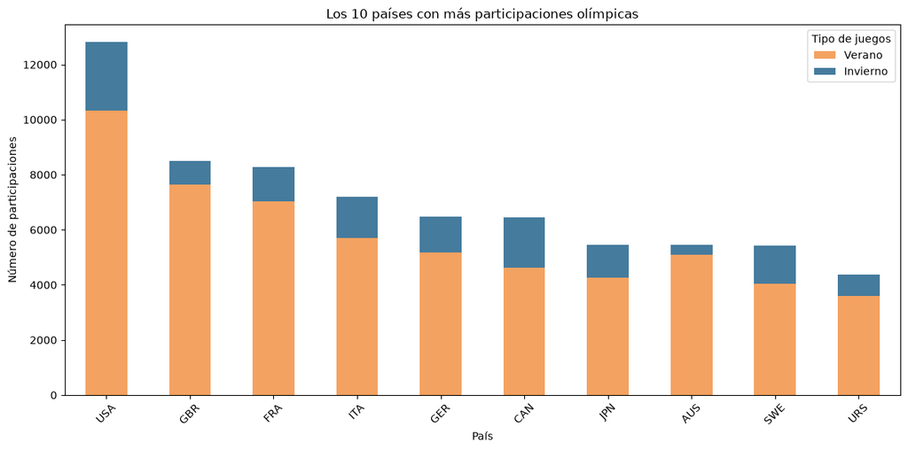

```python
participaciones = (
  athlete_medals_df
  .drop_duplicates(subset=["ID", "NOC", "Games"])
  .groupby(["NOC", "Season"])
  .size()
  .unstack(fill_value=0)
)
participaciones["Total"] = participaciones.sum(axis=1)
top10 = participaciones.nlargest(10, "Total")

ax = top10[["Summer", "Winter"]].rename(
    columns={"Summer": "Verano", "Winter": "Invierno"}
).plot(
    kind="bar",
    stacked=True,
    figsize=(12, 6),
    color=["#f4a261", "#457b9d"]
)

ax.set_title("Los 10 países con más participaciones olímpicas")
ax.set_xlabel("País")
ax.set_ylabel("Número de participaciones")
ax.legend(title="Tipo de juegos")
plt.xticks(rotation=45)
plt.tight_layout()
plt.show()
```

La elección del gráfico de barras apiladas es útil porque permite ver a simple vista que las participaciones en los Juegos de Verano son mucho más abundantes que en los Juegos de Invierno.

```
resumen_participacion(id_atleta, df_medallas)
```

Resume los años de participación de un atleta concreto en intervalos consecutivos y devuelva un diccionario con esa información

```python
def resumen_participacion(id_atleta, df):
  years = sorted(df.loc[df["ID"] == id_atleta, "Year"].unique())

  if not years:
    return {"ID": id_atleta, "participaciones": 0, "intervalos": []}

  intervals = []
  inicio = fin = int(years[0])

  for year in years[1:]:
    year = int(year)

    if year == fin + 4:
      fin = year
    else:
      intervals.append(f"{inicio}-{fin}")
      inicio = fin = year

  intervals.append(f"{inicio}-{fin}")
  return {"ID": id_atleta, "participaciones": len(years), "intervalos": intervals}
```

```python
resumen_participacion(id_atleta=94406, df=medals_df)
```

```
{'ID': 94406, 'participaciones': 5, 'intervalos': ['2000-2016']}
```

## 2. Perfil de los atletas

### Análisis

A continuación se obtendrán las edades medias de los atletas diferenciando entre juegos de verano e invierno. Es interesante ver que la edad de los atletas en el dataFrame es la del año en el que debutan, por lo que para computar años siguientes será importante sumarle +4 en función de los años que han pasado desde su debut.

```python
age_df = athlete_medals_df.copy()

# Extraemos el año de debut de cada atleta
age_df["Debut"] = age_df.groupby("ID")["Year"].transform("min")

# Calculamos para cada participación la edad del atleta
age_df["Age_of_participation"] = (
  age_df["Age"] + age_df["Year"] - age_df["Debut"]
)

# Eliminamos participaciones múltiples
age_df = age_df.drop_duplicates(subset=["ID", "Games"])

edades = (
  age_df
  .groupby("Season", as_index=False)
  .agg(Edad_media=("Age_of_participation", "mean"))
)

display(edades)
```

|  | Season | Edad_media |
| --- | --- | --- |
| 0 | Summer | 25.908560 |
| 1 | Winter | 25.102371 |

**Ahora se mostrará un histograma de edades de los 6 países con más atletas participantes**.

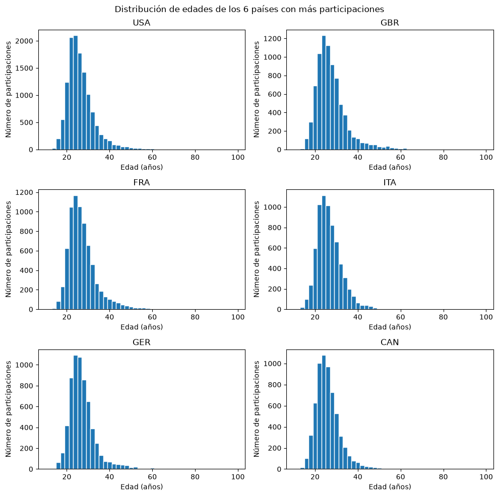

```python
top6_paises = participaciones.nlargest(6, "Total").index

datos = age_df.loc[age_df["NOC"].isin(top6_paises)]
edades_validas = datos["Age_of_participation"].dropna()

bins = range(
  int(edades_validas.min()),
  int(edades_validas.max()) + 3,
  2
)

fig, axes = plt.subplots(
  3, 2, figsize=(10, 10)
)
axes = axes.ravel()

for ax, pais in zip(axes, top6_paises):
  edades_pais = datos.loc[
    datos["NOC"] == pais, "Age_of_participation"
  ].dropna()

  ax.hist(edades_pais, bins=bins, edgecolor="white")
  ax.set_title(pais)
  ax.set_xlabel("Edad (años)")
  ax.set_ylabel("Número de participaciones")

fig.suptitle(
  "Distribución de edades de los 6 países con más participaciones"
)
plt.tight_layout()
plt.show()
```

**Ahora se mostrará la distribución porcentual entre hombres y mujeres y entre Juegos de Verano e Invierno**

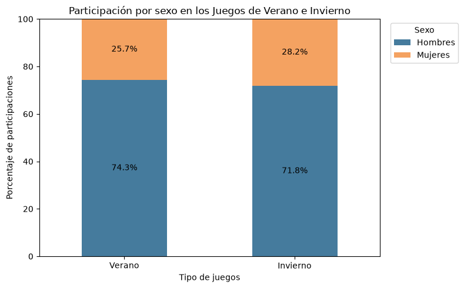

| Sex Season | F | M | Total | % Men | % Women |
| --- | --- | --- | --- | --- | --- |
| Summer | 40787 | 118072 | 158859 | 74.325030 | 25.674970 |
| Winter | 8054 | 20539 | 28593 | 71.832267 | 28.167733 |

```python
segregation = (
  athlete_medals_df
  .drop_duplicates(subset=["ID", "NOC", "Games"])
  .groupby(["Season", "Sex"])
  .size()
  .unstack(fill_value=0)
)

segregation["Total"] = segregation.sum(axis=1)
segregation["% Men"] = (segregation["M"] / segregation["Total"])*100
segregation["% Women"] = (segregation["F"] / segregation["Total"])*100

porcentajes = segregation[["% Men", "% Women"]].rename(
  index={"Summer": "Verano", "Winter": "Invierno"},
  columns={"% Men": "Hombres", "% Women": "Mujeres"}
)

ax = porcentajes.plot(
  kind="bar",
  stacked=True,
  figsize=(8, 5),
  color=["#457b9d", "#f4a261"],
  rot=0
)

for container in ax.containers:
  ax.bar_label(container, fmt="%.1f%%", label_type="center")

ax.set_title("Participación por sexo en los Juegos de Verano e Invierno")
ax.set_xlabel("Tipo de juegos")
ax.set_ylabel("Porcentaje de participaciones")
ax.set_ylim(0, 100)
ax.legend(title="Sexo", bbox_to_anchor=(1.02, 1), loc="upper left")

plt.tight_layout()
plt.show()

display(segregation)
```

**La elección del diagrama de barras apiladas es conveniente ya que permite ver cómo la suma de la proporción de hombres y mujeres conforma el 100% de participantes**

Ahora se mostrará la altura y el peso medio de las mujeres en los 5 deportes en los que haya más mujeres que hombres

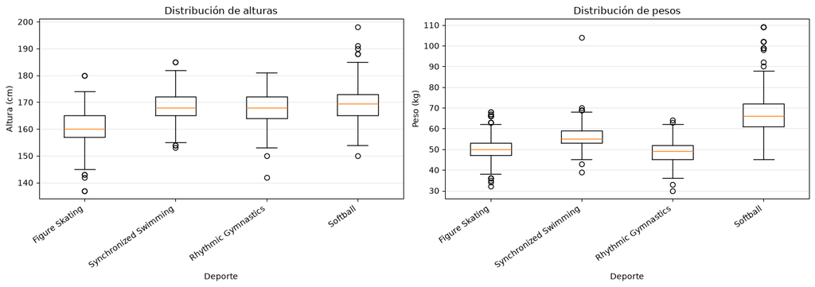

| Sex Sport | F | M |
| --- | --- | --- |
| Figure Skating | 1116 | 1066 |
| Synchronized Swimming | 728 | 0 |
| Rhythmic Gymnastics | 658 | 0 |
| Softball | 478 | 0 |

|  | Sport | Mujeres | Peso_medio | Altura_media |
| --- | --- | --- | --- | --- |
| 0 | Figure Skating | 1116 | 49.883941 | 160.636476 |
| 1 | Rhythmic Gymnastics | 658 | 48.760976 | 167.870253 |
| 2 | Softball | 478 | 67.471655 | 169.395089 |
| 3 | Synchronized Swimming | 728 | 55.795918 | 168.395415 |

```python
# Eliminamos los duplicados del dataFrame
athlete_medals_df_nodups = athlete_medals_df.drop_duplicates(subset=["ID", "NOC", "Games"])

women_sports_df = (
  athlete_medals_df_nodups
  .groupby(["Sport", "Sex"])
  .size()
  .unstack(fill_value=0)
)

# Extraemos los 5 deportes en los que las mujeres son más numerosas
women_sports = women_sports_df[women_sports_df["F"] > women_sports_df["M"]].sort_values("F", ascending=False).head(5)

# Ahora extraemos del dataFrame combinado las atletas cuyo deporte corresponde con los mencionados
datos = athlete_medals_df_nodups.loc[(athlete_medals_df["Sport"].isin(women_sports.index)) & (athlete_medals_df["Sex"] == "F")]

datos = datos[["Sport", "Weight", "Height"]]
final_df = (
  datos
  .groupby("Sport", as_index=False)
  .agg(
    Mujeres=("Sport", "size"),
    Peso_medio=("Weight", "mean"),
    Altura_media=("Height", "mean")
  )
)

fig, axes = plt.subplots(1, 2, figsize=(14, 5))

for ax, variable, titulo, unidad in [
  (axes[0], "Height", "Distribución de alturas", "Altura (cm)"),
  (axes[1], "Weight", "Distribución de pesos", "Peso (kg)")
]:
  valores = [
    datos.loc[datos["Sport"].eq(deporte), variable].dropna()
    for deporte in women_sports.index
  ]

  ax.boxplot(valores)
  ax.set_xticks(range(1, len(women_sports.index) + 1))
  ax.set_xticklabels(women_sports.index, rotation=35, ha="right")
  ax.set_title(titulo)
  ax.set_xlabel("Deporte")
  ax.set_ylabel(unidad)
  ax.grid(axis="y", alpha=0.3)

plt.tight_layout()
plt.show()

display(women_sports)
display(final_df)
```

De los datos extraídos vemos que en realidad hay menos de **5 deportes donde las mujeres compiten en mayor cantidad que los hombres**, y no 5 como se proponía inicialmente. Además, deportes como la Gimnasia Rítmica, el Softball y la Natación Sincronizada son **practicados exclusivamente por mujeres.**

```
extremos_atletas(df_atletas)
```

Devuelve un diccionario con los/las atletas “extremos” (más joven, más mayor, de mayor/menor altitud, y de mayor/menor peso), aplicando ciertas reglas de desempate.

- Debe descartar registros sin valor numérico válido, es decir edades, alturas o pesos nulos o no plausibles (" outliers”).
- Cuando haya empates, desempatar por más participaciones olímpicas (si hay información), y si persiste, por orden alfabético de nombre.

Para definir qué valores dejar fuera como outliers se hará un plot de las columnas para poder decidir

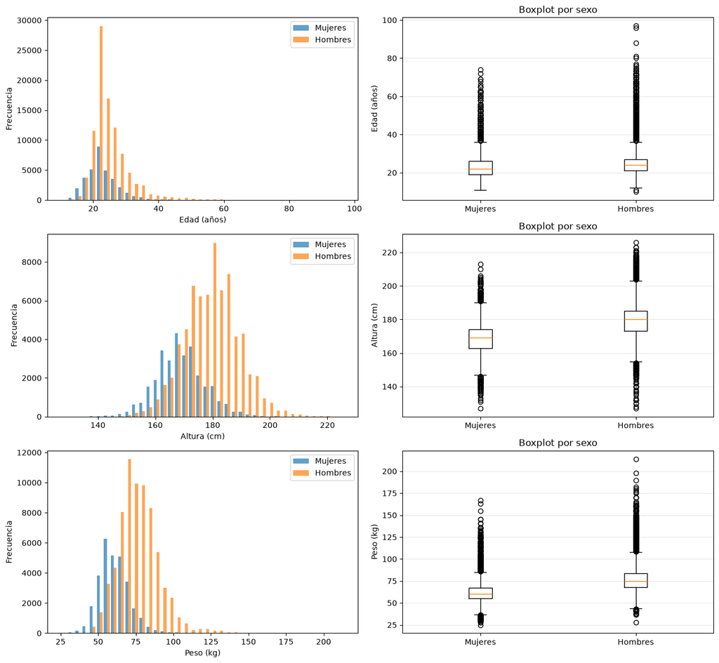

```python
variables = {
  "Age": "Edad (años)",
  "Height": "Altura (cm)",
  "Weight": "Peso (kg)",
}

fig, axes = plt.subplots(3, 2, figsize=(13, 12))

for fila, (columna, etiqueta) in enumerate(variables.items()):
  grupos = [
    athletes_df.loc[athletes_df["Sex"].eq(sexo), columna].dropna()
    for sexo in ["F", "M"]
  ]

  ax_hist, ax_box = axes[fila]

  ax_hist.hist(
    grupos,
    bins=40,
    label=["Mujeres", "Hombres"],
    alpha=0.7
  )
  ax_hist.set_xlabel(etiqueta)
  ax_hist.set_ylabel("Frecuencia")
  ax_hist.legend()

  ax_box.boxplot(grupos)
  ax_box.set_xticks([1, 2])
  ax_box.set_xticklabels(["Mujeres", "Hombres"])
  ax_box.set_ylabel(etiqueta)
  ax_box.set_title("Boxplot por sexo")
  ax_box.grid(axis="y", alpha=0.3)

plt.tight_layout()
plt.show()
```

Por los histogramas y de los diagramas de caja y bigotes para cada característica puede verse que hay un gran número de valores atípicos en todas las variables analizadas. Tras estudiar el dataset y sus valores más extremos estableceremos los siguientes umbrales:

- La edad máxima a la que se establecerá la participación será a los **74 años**. Esto es debido a que en la historia de los juegos olímpicos nadie ha rebasado esta edad. Todos aquellos participantes con edades superiores son personalidades históricas cuyas obras o acciones han sido parte de algunos juegos, como es el caso de John Quincy Adams Ward, un escultor americano que participó póstumamente en la Competencia de Artes de los juegos del 1910.
- La edad mínima **será de 10 años**, ya que pertenece a la del participante más joven en la historia de los juegos.

El resto de medidas, aunque extremas, corresponden todas a valores reales de deportistas que han competido en los JJ.OO

```python
def extremos_atletas(df):
  criterios = {
    "mas_joven": ("Age", "min", "edad"),
    "mas_mayor": ("Age", "max", "edad"),
    "mas_alto": ("Height", "max", "altura"),
    "mas_bajo": ("Height", "min", "altura"),
    "mas_ligero": ("Weight", "min", "peso"),
    "mas_pesado": ("Weight", "max", "peso"),
  }
  resultados = {}

  for tag, (columna, extremo, key) in criterios.items():

    # Descartamos N/A - NaN
    valores = df[columna].dropna()

    # Descartamos outliers
    if columna == "Age":
      valores = valores[valores.between(10, 74)]

    # Descartamos valores vacíos
    if valores.empty:
      resultados[tag] = None
      continue

    # Extracción index
    valor_extremo = (
      valores.min()
      if extremo == "min"
      else valores.max()
    )

    indices = valores.index[valores.eq(valor_extremo)]
    empatados = df.loc[indices]

    empatados["participaciones"] = empatados["ID"].map(
      lambda id_atleta: resumen_participacion(
        id_atleta=id_atleta,
        df=medals_df
      )["participaciones"]
    )

    # Más participaciones primero; después, nombre alfabético.
    elegido = empatados.sort_values(
      ["participaciones", "Name"],
      ascending=[False, True]
    ).iloc[0]

    resumen_participacion(id_atleta=94406, df=medals_df)

    #Inserción Diccionario
    resultados[tag] = {
      "id": int(elegido["ID"]),
      "nombre": elegido["Name"],
      key: float(elegido[columna])
    }

  return resultados

extremos_atletas(athletes_df)
```

```
{'mas_joven': {'id': 71691, 'nombre': 'Dimitrios Loundras', 'edad': 10.0},
 'mas_mayor': {'id': 93535, 'nombre': 'Auguste Perret', 'edad': 74.0},
 'mas_alto': {'id': 132627, 'nombre': 'Yao Ming', 'altura': 226.0},
 'mas_bajo': {'id': 82769, 'nombre': 'Lyton Levison Mphande', 'altura': 127.0},
 'mas_ligero': {'id': 21049, 'nombre': 'Choi Myong-Hui', 'peso': 25.0},
 'mas_pesado': {'id': 12177, 'nombre': 'Ricardo Blas, Jr.', 'peso': 214.0}}
```

## 3. Cantidad de medallas y rendimiento

### Análisis

A continuación se obtendrá un mapa de calor de país × deporte (en el que la intensidad sea el número total de medallas). Para favorecer la claridad se mostrarán únicamente los 30 países con más medallas

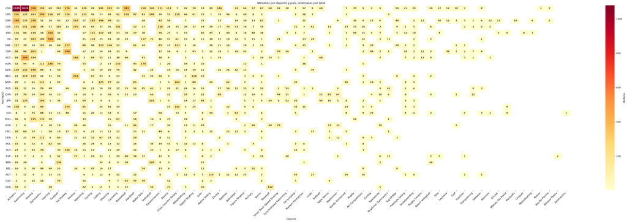

```python
# Descartamos filas donde no se ha ganado ninguna medalla
medallas = athlete_medals_df.dropna(subset=["Medal"])

# Recuento de medallas por deporte para cada país
tabla = pd.crosstab(medallas["NOC"], medallas["Sport"])
tabla = tabla.loc[
  tabla.sum(axis=1).sort_values(ascending=False).index,
  tabla.sum(axis=0).sort_values(ascending=False).index
].head(30)

fig, ax = plt.subplots(
  figsize=(
    max(30, len(tabla.columns) * 0.65),
    max(12, len(tabla) * 0.45)
  )
)

sns.heatmap(
  tabla,
  mask=tabla.eq(0),
  annot=True,
  fmt="d",
  annot_kws={"fontsize": 10, "fontweight": "bold"},
  cmap="YlOrRd",
  linewidths=0.3,
  linecolor="white",
  xticklabels=True,
  yticklabels=True,
  cbar_kws={"label": "Medallas"},
  ax=ax
)

ax.set_xticklabels(
  ax.get_xticklabels(), rotation=45, ha="right", fontsize=11
)
ax.set_yticklabels(
  ax.get_yticklabels(), rotation=0, fontsize=11
)
ax.set_xlabel("Deporte")
ax.set_ylabel("País (NOC)")
ax.set_title("Medallas por deporte y país, ordenadas por total")

plt.tight_layout()
plt.show()
```

**Ahora el ranquin de los 10 países con mayor número total de medallas (de cualquier tipo) y, para cada uno de esos 10 países, el deporte en el que más medallas ha conseguido**

```python
# Descartamos filas donde no se ha ganado ninguna medalla
medallas = athlete_medals_df.dropna(subset=["Medal"])

# Recuento de medallas por deporte para cada país
tabla = pd.crosstab(medallas["NOC"], medallas["Sport"])
tabla = tabla.loc[
  tabla.sum(axis=1).sort_values(ascending=False).index,
  tabla.sum(axis=0).sort_values(ascending=False).index
].head(10)

tabla["Deporte_mas_laureado"] = tabla.idxmax(axis=1)
tabla["Total_medallas"] = tabla.drop(
  columns="Deporte_mas_laureado"
).sum(axis=1)

display(tabla[["Total_medallas", "Deporte_mas_laureado"]])
```

| Sport NOC | Total_medallas | Deporte_mas_laureado |
| --- | --- | --- |
| USA | 5633 | Athletics |
| URS | 2660 | Gymnastics |
| GBR | 2075 | Athletics |
| GER | 2049 | Rowing |
| FRA | 1773 | Fencing |
| ITA | 1627 | Fencing |
| SWE | 1535 | Ice Hockey |
| CAN | 1347 | Ice Hockey |
| AUS | 1314 | Swimming |
| HUN | 1131 | Fencing |

**Ahora se mostrarán los 5 países líderes en medallas, y su evolución por décadas de su cantidad de medallas.**

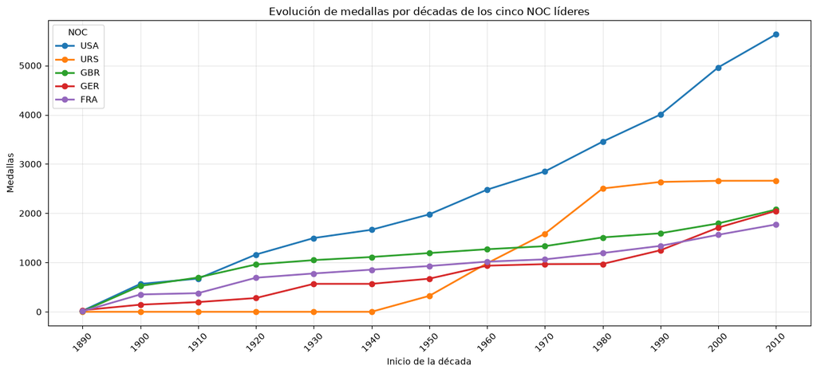

| NOC Decada | USA | URS | GBR | GER | FRA |
| --- | --- | --- | --- | --- | --- |
| 1890 | 20 | 0 | 9 | 32 | 11 |
| 1900 | 566 | 0 | 526 | 144 | 352 |
| 1910 | 673 | 0 | 696 | 197 | 378 |
| 1920 | 1162 | 0 | 961 | 279 | 691 |
| 1930 | 1497 | 0 | 1049 | 567 | 778 |
| 1940 | 1665 | 0 | 1112 | 567 | 855 |
| 1950 | 1978 | 323 | 1192 | 672 | 929 |
| 1960 | 2479 | 984 | 1270 | 936 | 1018 |
| 1970 | 2849 | 1585 | 1332 | 967 | 1064 |
| 1980 | 3454 | 2503 | 1510 | 971 | 1192 |
| 1990 | 4004 | 2636 | 1594 | 1249 | 1338 |
| 2000 | 4961 | 2659 | 1794 | 1709 | 1563 |
| 2010 | 5633 | 2660 | 2075 | 2049 | 1773 |

```python
medallas = athlete_medals_df.dropna(subset=["Medal"]).copy()

# Cinco países/NOC con más medallas en todo el periodo.
lideres = medallas["NOC"].value_counts().head(5).index

# Cada década se identifica por su año inicial.
medallas["Decada"] = (medallas["Year"] // 10) * 10

evolucion = pd.crosstab(
  medallas["Decada"],
  medallas["NOC"]
).reindex(columns=lideres, fill_value=0)

# Incluimos todas las décadas del periodo estudiado.
decadas = range(
  int(medallas["Decada"].min()),
  int(medallas["Decada"].max()) + 10,
  10
)
evolucion = evolucion.cumsum(axis=0)

ax = evolucion.plot(
  figsize=(13, 6),
  marker="o",
  linewidth=2
)

ax.set_xlabel("Inicio de la década")
ax.set_ylabel("Medallas")
ax.set_title("Evolución de medallas por décadas de los cinco NOC líderes")
ax.set_xticks(evolucion.index)
ax.tick_params(axis="x", rotation=45)
ax.legend(title="NOC")
ax.grid(alpha=0.3)

plt.tight_layout()
plt.show()

display(evolucion)
```

A continuación se elige **la gimnasia** para analizar si hay relación entre la altura/peso de los deportistas y probabilidad de medalla en función del país. Tras ello también compararemos todos los países para el deporte elegido. Por claridad en los resultados separaremos las distribuciones de Gimnastas entre hombre y mujer.

|  | ID | Name | NOC | Altura | Peso | Eventos | Numero_medallas | laureatus_rating |
| --- | --- | --- | --- | --- | --- | --- | --- | --- |
| 64 | 4198 | Nikolay Yefimovich Andrianov | URS | 166.0 | 60.0 | 24 | 15 | 0.625000 |
| 1716 | 89187 | Takashi Ono | JPN | 160.0 | 58.0 | 32 | 13 | 0.406250 |
| 2093 | 109161 | Borys Anfiyanovych Shakhlin | URS | 171.0 | 71.0 | 24 | 13 | 0.541667 |
| 1100 | 57998 | Sawao Kato | JPN | 163.0 | 59.0 | 24 | 12 | 0.500000 |
| 1644 | 85286 | Aleksey Yuryevich Nemov | RUS | 174.0 | 75.0 | 21 | 12 | 0.571429 |
| ... | ... | ... | ... | ... | ... | ... | ... | ... |
| 1023 | 54248 | Alexander "Sasha" Jeltkov | CAN | 178.0 | 78.0 | 11 | 0 | 0.000000 |
| 1030 | 54442 | Sidney "Sid" Jensen | CAN | 168.0 | 63.0 | 8 | 0 | 0.000000 |
| 1033 | 54559 | Jeong Jin-Su | KOR | 160.0 | 55.0 | 24 | 0 | 0.000000 |
| 1034 | 54574 | Jeong Ri-Gwang | KOR | 162.0 | 58.0 | 8 | 0 | 0.000000 |
| 990 | 52801 | Ivan Yanev Ivanov | BUL | 158.0 | 56.0 | 7 | 0 | 0.000000 |

1042 rows × 8 columns

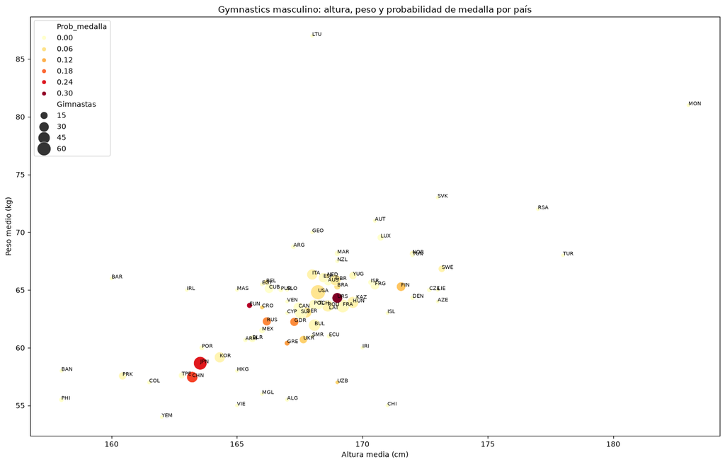

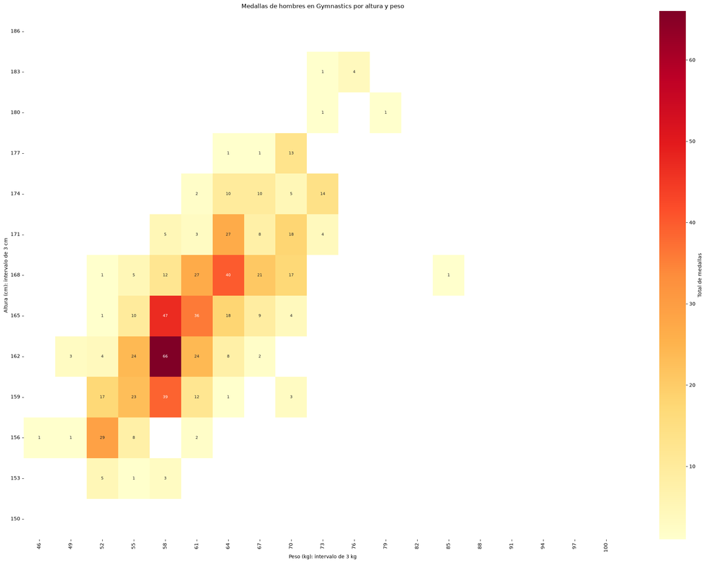

|  | ID | Name | NOC | Altura | Peso | Eventos | Numero_medallas | laureatus_rating |
| --- | --- | --- | --- | --- | --- | --- | --- | --- |
| 691 | 67046 | Larysa Semenivna Latynina (Diriy-) | URS | 161.0 | 52.0 | 19 | 18 | 0.947368 |
| 176 | 18826 | Vra slavsk (-Odloilov) | TCH | 160.0 | 58.0 | 18 | 11 | 0.611111 |
| 39 | 5700 | Polina Hryhorivna Astakhova | URS | 166.0 | 56.0 | 19 | 10 | 0.526316 |
| 216 | 22570 | Nadia Elena Comneci (-Conner) | ROU | 162.0 | 45.0 | 12 | 9 | 0.750000 |
| 1336 | 122726 | Lyudmila Ivanovna Turishcheva (-Borzova) | URS | 160.0 | 52.0 | 18 | 9 | 0.500000 |
| ... | ... | ... | ... | ... | ... | ... | ... | ... |
| 594 | 58603 | Karen Barbara Kelsall | CAN | 150.0 | 37.0 | 6 | 0 | 0.000000 |
| 595 | 58720 | Karen Kennedy | GBR | 162.0 | 50.0 | 5 | 0 | 0.000000 |
| 596 | 58821 | Angelika Kern | FRG | 158.0 | 46.0 | 12 | 0 | 0.000000 |
| 600 | 58934 | Rose-Marie "Romi" Kessler | SUI | 159.0 | 48.0 | 6 | 0 | 0.000000 |
| 571 | 56612 | Ariella Kaeslin | SUI | 165.0 | 55.0 | 5 | 0 | 0.000000 |

1130 rows × 8 columns

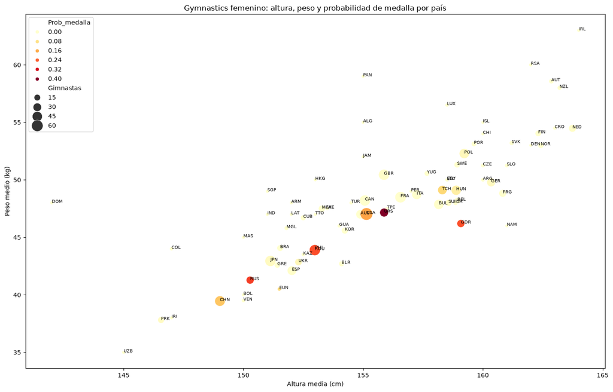

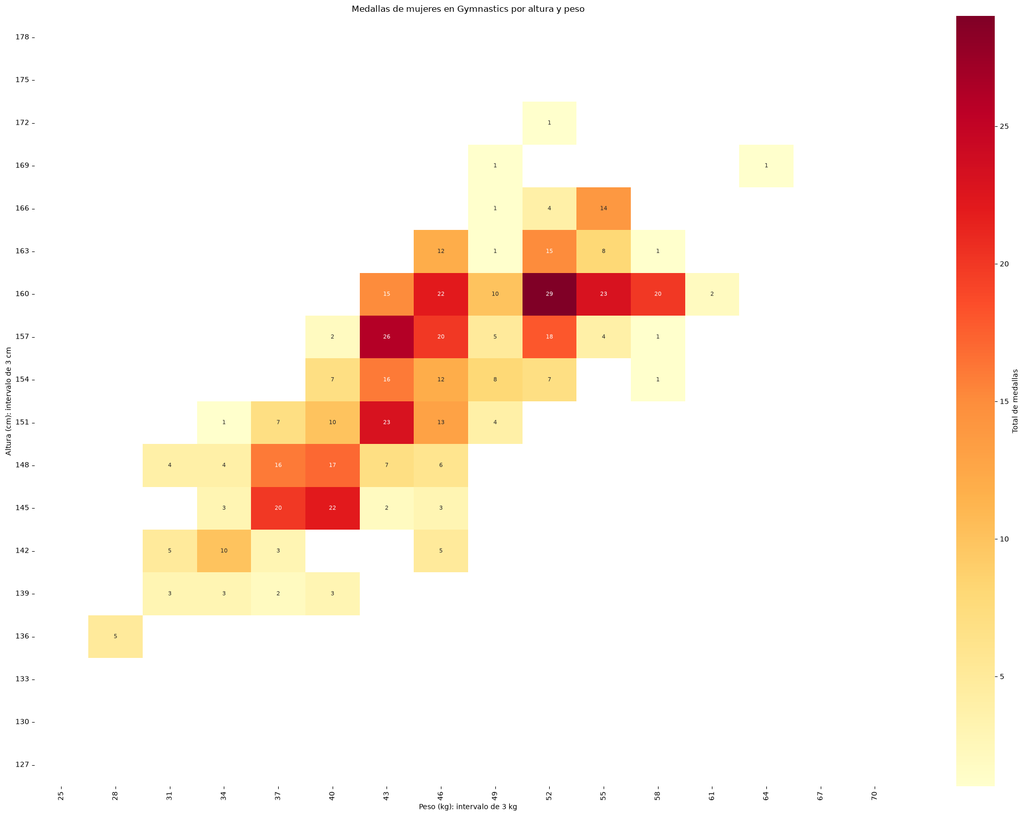

```python
deporte = "Gymnastics"

# -------------------------
# FILTRAMOS POR SEXO
# -------------------------

deporte_males = athlete_medals_df.loc[
  (athlete_medals_df["Sport"] == deporte)
  & (athlete_medals_df["Sex"] == "M")
]

deporte_females = athlete_medals_df.loc[
  (athlete_medals_df["Sport"] == deporte)
  & (athlete_medals_df["Sex"] == "F")
]

# -------------------------
# AGRUPAMOS POR DEPORTISTA
# -------------------------

deporte_males = (
  deporte_males
  .groupby("ID", as_index=False)
  .agg(
    Name=("Name", "first"),
    NOC=("NOC", "first"),
    Altura=("Height", "first"),
    Peso=("Weight", "first"),
    Eventos=("ID", "size"),
    Numero_medallas=("Medal", "count")
)
).dropna(subset=["Altura", "Peso"]).sort_values(
  "Numero_medallas", ascending=False
)

deporte_females = (
  deporte_females
  .groupby("ID", as_index=False)
  .agg(
    Name=("Name", "first"),
    NOC=("NOC", "first"),
    Altura=("Height", "first"),
    Peso=("Weight", "first"),
    Eventos=("ID", "size"),
    Numero_medallas=("Medal", "count")
  )
).dropna(subset=["Altura", "Peso"]).sort_values(
  "Numero_medallas", ascending=False
)

# Ratio individual de medallas
deporte_males["laureatus_rating"] = (
  deporte_males["Numero_medallas"] / deporte_males["Eventos"]
)

deporte_females["laureatus_rating"] = (
  deporte_females["Numero_medallas"] / deporte_females["Eventos"]
)

# =========================================================
# HOMBRES
# =========================================================

display(deporte_males)

# Agrupamos por país
paises_hombres = (
  deporte_males
  .groupby("NOC", as_index=False)
  .agg(
    Altura=("Altura", "mean"),
    Peso=("Peso", "mean"),
    Eventos=("Eventos", "sum"),
    Medallas=("Numero_medallas", "sum"),
    Gimnastas=("ID", "count")
  )
)

# Probabilidad de medalla
paises_hombres["Prob_medalla"] = (
  paises_hombres["Medallas"] / paises_hombres["Eventos"]
)


# SCATTERPLOT HOMBRES
plt.figure(figsize=(14, 9))

sns.scatterplot(
  data=paises_hombres,
  x="Altura",
  y="Peso",
  hue="Prob_medalla",
  size="Gimnastas",
  sizes=(30, 400),
  palette="YlOrRd"
)

for _, fila in paises_hombres.iterrows():
  plt.text(
    fila["Altura"],
    fila["Peso"],
    fila["NOC"],
    fontsize=7
  )

plt.xlabel("Altura media (cm)")
plt.ylabel("Peso medio (kg)")
plt.title(
  f"{deporte} masculino: altura, peso y probabilidad de medalla por país"
)
plt.tight_layout()
plt.show()


# HEATMAP HOMBRES
datos = deporte_males.copy()

limites_altura = np.arange(
  np.floor(datos["Altura"].min()),
  np.floor(datos["Altura"].max()) + 3,
  3
)

limites_peso = np.arange(
  np.floor(datos["Peso"].min()),
  np.floor(datos["Peso"].max()) + 3,
  3
)

datos["Grupo_altura"] = pd.cut(
  datos["Altura"],
  bins=limites_altura,
  right=False
)

datos["Grupo_peso"] = pd.cut(
  datos["Peso"],
  bins=limites_peso,
  right=False
)

tabla = datos.pivot_table(
  index="Grupo_altura",
  columns="Grupo_peso",
  values="Numero_medallas",
  aggfunc="sum",
  observed=False,
  fill_value=0
)

tabla.index = tabla.index.categories.left.astype(int)
tabla.columns = tabla.columns.categories.left.astype(int)

fig, ax = plt.subplots(figsize=(22, 16))

sns.heatmap(
  tabla,
  mask=tabla.eq(0),
  annot=True,
  fmt=".0f",
  annot_kws={"fontsize": 8},
  cmap="YlOrRd",
  cbar_kws={"label": "Total de medallas"},
  ax=ax
)

ax.invert_yaxis()
ax.set_xlabel("Peso (kg): intervalo de 3 kg")
ax.set_ylabel("Altura (cm): intervalo de 3 cm")
ax.set_title(
  f"Medallas de hombres en {deporte} por altura y peso"
)

plt.xticks(rotation=90)
plt.yticks(rotation=0)
plt.tight_layout()
plt.show()


# =========================================================
# MUJERES
# =========================================================

display(deporte_females)

# Agrupamos por país
paises_mujeres = (
  deporte_females
  .groupby("NOC", as_index=False)
  .agg(
    Altura=("Altura", "mean"),
    Peso=("Peso", "mean"),
    Eventos=("Eventos", "sum"),
    Medallas=("Numero_medallas", "sum"),
    Gimnastas=("ID", "count")
  )
)

# Probabilidad de medalla
paises_mujeres["Prob_medalla"] = (
  paises_mujeres["Medallas"] / paises_mujeres["Eventos"]
)

# SCATTERPLOT MUJERES
plt.figure(figsize=(14, 9))

sns.scatterplot(
  data=paises_mujeres,
  x="Altura",
  y="Peso",
  hue="Prob_medalla",
  size="Gimnastas",
  sizes=(30, 400),
  palette="YlOrRd"
)

for _, fila in paises_mujeres.iterrows():
  plt.text(
    fila["Altura"],
    fila["Peso"],
    fila["NOC"],
    fontsize=7
  )

plt.xlabel("Altura media (cm)")
plt.ylabel("Peso medio (kg)")
plt.title(
  f"{deporte} femenino: altura, peso y probabilidad de medalla por país"
)
plt.tight_layout()
plt.show()


# HEATMAP MUJERES
datos = deporte_females.copy()

limites_altura = np.arange(
  np.floor(datos["Altura"].min()),
  np.floor(datos["Altura"].max()) + 3,
  3
)

limites_peso = np.arange(
  np.floor(datos["Peso"].min()),
  np.floor(datos["Peso"].max()) + 3,
  3
)

datos["Grupo_altura"] = pd.cut(
  datos["Altura"],
  bins=limites_altura,
  right=False
)

datos["Grupo_peso"] = pd.cut(
  datos["Peso"],
  bins=limites_peso,
  right=False
)

tabla = datos.pivot_table(
  index="Grupo_altura",
  columns="Grupo_peso",
  values="Numero_medallas",
  aggfunc="sum",
  observed=False,
  fill_value=0
)

tabla.index = tabla.index.categories.left.astype(int)
tabla.columns = tabla.columns.categories.left.astype(int)

fig, ax = plt.subplots(figsize=(22, 16))

sns.heatmap(
  tabla,
  mask=tabla.eq(0),
  annot=True,
  fmt=".0f",
  annot_kws={"fontsize": 8},
  cmap="YlOrRd",
  cbar_kws={"label": "Total de medallas"},
  ax=ax
)

ax.invert_yaxis()
ax.set_xlabel("Peso (kg): intervalo de 3 kg")
ax.set_ylabel("Altura (cm): intervalo de 3 cm")
ax.set_title(
  f"Medallas de mujeres en {deporte} por altura y peso"
)

plt.xticks(rotation=90)
plt.yticks(rotation=0)
plt.tight_layout()
plt.show()
```

En los hombres, la mayoría de las medallas se concentra aproximadamente entre 159–168 cm de altura y 55–67 kg de peso. El scatterplot masculino está sesgado, y se concentra en el cuadrante inferior izquierdo de la gráfica. Esto quiere decir que la gimnasia favorece las estaturas bajas y los pesos ligeros. El heatmap también permite ver que un peso ligero influye más en la probabilidad de medalla que una altura baja.

En las mujeres, las medallas se concentran principalmente entre 145–160 cm y 37–55 kg. Ellas presentan una distribución más equilibrada que los hombres, con valores un poco más dispersos. De media, y como en otros deportes, presentan una altura y peso inferiores a los de los hombres.

```
ranking_paises_medallas(df_medallas, k)
```

Devuelve devuelva el Top-k de países, siguiendo una serie de reglas de desempate:

1. El país con más oros
2. Si empatan, el de más platas
3. Si empatan, el de más bronces
4. Si empatan, el del primer año en que el país logró una medalla de cualquier tipo (más antiguo gana)
5. Si persiste el empate, por orden alfabético del país

```python
def ranking_paises_medallas(df, k):
  response = []
  datos = (
    df.groupby("NOC", as_index=False)
    .agg(
      Golds=("Medal", lambda s: (s == "Gold").sum()),
      Silvers=("Medal", lambda s: (s == "Silver").sum()),
      Bronzes=("Medal", lambda s: (s == "Bronze").sum()),
      Eventos=("ID", "size"),
      Numero_medallas=("Medal", "count"),
      Primera_participacion=("Year", "min")
    )
    .sort_values("Numero_medallas", ascending=False)
    .reset_index(drop=True)
  ).sort_values(
    ["Golds", "Silvers", "Bronzes", "Primera_participacion", "NOC"],
    ascending=[False, False, False, True, True]
  ).head(k)

  for index, (_, row) in enumerate(datos.iterrows()):
    response.append({
        "orden": index + 1,
        "país": row["NOC"],
        "oro": row["Golds"],
        "plata": row["Silvers"],
        "bronce": row["Bronzes"],
        "primer_año": row["Primera_participacion"],
      }
    )

  for item in response:
    print(item)

ranking_paises_medallas(athlete_medals_df, 10)
```

```
{'orden': 1, 'país': 'USA', 'oro': 2637, 'plata': 1642, 'bronce': 1354, 'primer_año': 1896}
{'orden': 2, 'país': 'URS', 'oro': 1137, 'plata': 783, 'bronce': 740, 'primer_año': 1952}
{'orden': 3, 'país': 'GER', 'oro': 690, 'plata': 647, 'bronce': 712, 'primer_año': 1896}
{'orden': 4, 'país': 'GBR', 'oro': 679, 'plata': 743, 'bronce': 653, 'primer_año': 1896}
{'orden': 5, 'país': 'ITA', 'oro': 574, 'plata': 525, 'bronce': 528, 'primer_año': 1896}
{'orden': 6, 'país': 'FRA', 'oro': 500, 'plata': 607, 'bronce': 666, 'primer_año': 1896}
{'orden': 7, 'país': 'SWE', 'oro': 478, 'plata': 522, 'bronce': 535, 'primer_año': 1896}
{'orden': 8, 'país': 'CAN', 'oro': 462, 'plata': 435, 'bronce': 450, 'primer_año': 1900}
{'orden': 9, 'país': 'GDR', 'oro': 437, 'plata': 345, 'bronce': 302, 'primer_año': 1968}
{'orden': 10, 'país': 'HUN', 'oro': 429, 'plata': 331, 'bronce': 371, 'primer_año': 1896}
```

## 4. Mujeres en los JJ.OO

### Análisis

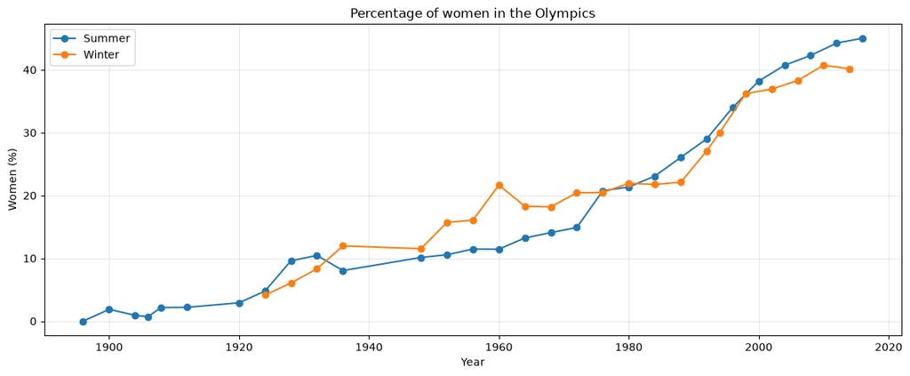

```python
summer = (
  athlete_medals_df
  .loc[athlete_medals_df["Season"] == "Summer"]
  .drop_duplicates(subset=["ID", "NOC", "Games"])
  .groupby("Year", as_index=False)
  .agg(
    Males=("Sex", lambda s: (s == "M").sum()),
    Females=("Sex", lambda s: (s == "F").sum()),
    Total=("Sex", lambda s: ((s == "M") | (s == "F")).sum())
  )
  .assign(Proportion = lambda df: df["Females"] / (df["Males"] + df["Females"]))
)

winter = (
  athlete_medals_df
  .loc[athlete_medals_df["Season"] == "Winter"]
  .drop_duplicates(subset=["ID", "NOC", "Games"])
  .groupby("Year", as_index=False)
  .agg(
    Males=("Sex", lambda s: (s == "M").sum()),
    Females=("Sex", lambda s: (s == "F").sum()),
    Total=("Sex", lambda s: ((s == "M") | (s == "F")).sum())
  )
  .assign(Proportion = lambda df: df["Females"] / (df["Males"] + df["Females"]))
)

plt.figure(figsize=(12, 5))

plt.plot(summer["Year"], summer["Proportion"] * 100, marker="o", label="Summer")
plt.plot(winter["Year"], winter["Proportion"] * 100, marker="o", label="Winter")

plt.xlabel("Year")
plt.ylabel("Women (%)")
plt.title("Percentage of women in the Olympics")
plt.legend()
plt.grid(alpha=0.3)
plt.tight_layout()
plt.show()
```

Se puede ver el crecimiento de la proporción de participantes mujer en los Juegos tanto en los de verano como los de invierno, aunque la presencia de la mujer en los juegos de invierno empieza mucho después, en 1924.

Este gráfico es el más adecuado para visualizar estos datos ya que permite comparar a simple vista el crecimiento en ambos juegos a lo largo del tiempo y permite inferir cuál sería la participación masculina fácilmente.

|  | Sport | First_year_for_women |
| --- | --- | --- |
| 0 | Croquet | 1900 |
| 1 | Equestrianism | 1900 |
| 2 | Golf | 1900 |
| 3 | Sailing | 1900 |
| 4 | Tennis | 1900 |
| 5 | Archery | 1904 |
| 6 | Motorboating | 1908 |
| 7 | Figure Skating | 1908 |
| 8 | Diving | 1912 |
| 9 | Swimming | 1912 |
| 10 | Art Competitions | 1920 |
| 11 | Fencing | 1924 |
| 12 | Athletics | 1928 |
| 13 | Gymnastics | 1928 |
| 14 | Alpinism | 1936 |
| 15 | Alpine Skiing | 1936 |
| 16 | Canoeing | 1948 |
| 17 | Cross Country Skiing | 1952 |
| 18 | Speed Skating | 1960 |
| 19 | Volleyball | 1964 |

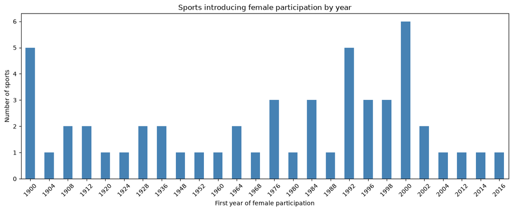

```python
participations = athlete_medals_df.drop_duplicates(
  subset=["ID", "NOC", "Games", "Sport"]
)

first_year_for_women = (
  participations.loc[participations["Sex"] == "F"]
  .groupby("Sport")["Year"]
  .min()
  .rename("First_year_for_women")
  .sort_values(ascending=True)
  .reset_index()
)

display(first_year_for_women.head(20))

sports_per_year = (
  first_year_for_women["First_year_for_women"]
  .value_counts()
  .sort_index()
)

sports_per_year.plot.bar(figsize=(12, 5), color="steelblue")

plt.xlabel("First year of female participation")
plt.ylabel("Number of sports")
plt.title("Sports introducing female participation by year")
plt.xticks(rotation=45)
plt.tight_layout()
plt.show()
```

**A continuación un análisis de aquellos países con mayor representación femenina histórica**, separado de nuevo por participaciones en los juegos de Verano e Invierno. Se mostrará un top 10. Para mayor claridad excluiremos los países con menos de 100 participaciones del análisis.

```python
summer = (
  athlete_medals_df
  .loc[athlete_medals_df["Season"] == "Summer"]
  .drop_duplicates(subset=["ID", "NOC", "Games"])
  .groupby(["NOC"], as_index=False)
  .agg(
    Males=("Sex", lambda s: (s == "M").sum()),
    Females=("Sex", lambda s: (s == "F").sum()),
    Total=("Sex", lambda s: ((s == "M") | (s == "F")).sum())
  )
  .loc[lambda df: df["Total"] >= 100]
  .assign(Proportion = lambda df: df["Females"] / (df["Males"] + df["Females"]))
  .sort_values(["Proportion", "Females", "NOC"], ascending=[False, False, False])
).head(10)

winter = (
  athlete_medals_df
  .loc[athlete_medals_df["Season"] == "Winter"]
  .drop_duplicates(subset=["ID", "NOC", "Games"])
  .groupby(["NOC"], as_index=False)
  .agg(
    Males=("Sex", lambda s: (s == "M").sum()),
    Females=("Sex", lambda s: (s == "F").sum()),
    Total=("Sex", lambda s: ((s == "M") | (s == "F")).sum())
  )
  .loc[lambda df: df["Total"] >= 100]
  .assign(Proportion = lambda df: df["Females"] / (df["Males"] + df["Females"]))
  .sort_values(["Proportion", "Females", "NOC"], ascending=[False, False, False])
).head(10)

display(summer)
display(winter)
```

|  | NOC | Males | Females | Total | Proportion |
| --- | --- | --- | --- | --- | --- |
| 41 | CHN | 1443 | 1700 | 3143 | 0.540885 |
| 5 | ANG | 125 | 117 | 242 | 0.483471 |
| 25 | BLR | 451 | 401 | 852 | 0.470657 |
| 164 | PRK | 223 | 195 | 418 | 0.466507 |
| 212 | UKR | 713 | 623 | 1336 | 0.466317 |
| 220 | VIE | 67 | 56 | 123 | 0.455285 |
| 171 | RUS | 1343 | 1080 | 2423 | 0.445728 |
| 102 | JAM | 322 | 236 | 558 | 0.422939 |
| 54 | CZE | 405 | 275 | 680 | 0.404412 |
| 105 | KAZ | 392 | 265 | 657 | 0.403349 |

|  | NOC | Males | Females | Total | Proportion |
| --- | --- | --- | --- | --- | --- |
| 20 | CHN | 186 | 288 | 474 | 0.607595 |
| 111 | UKR | 166 | 136 | 302 | 0.450331 |
| 92 | RUS | 492 | 345 | 837 | 0.412186 |
| 78 | NED | 196 | 133 | 329 | 0.404255 |
| 33 | EUN | 131 | 82 | 213 | 0.384977 |
| 48 | HUN | 174 | 105 | 279 | 0.376344 |
| 81 | NZL | 73 | 43 | 116 | 0.370690 |
| 7 | AUS | 221 | 121 | 342 | 0.353801 |
| 60 | KAZ | 173 | 94 | 267 | 0.352060 |
| 17 | CAN | 1189 | 632 | 1821 | 0.347062 |

Del análisis se extrae que China lidera el ranking en representación femenina. Más de la mitad de sus atletas en la historia de los juegos han sido mujeres, tanto para sus juegos de invierno como de verano.

**Ahora se verá qué deportes han tenido el mayor crecimiento de participación femenina**. El criterio de crecimiento será aquel año en que la diferencia de participación femenina con el primer año del registro sea la mayor (atendiendo al porcentaje de mujeres con respecto al de hombres).

|  | Sport | First_year | First_women | First_percentage | Latest_year | Latest_women | Latest_percentage | Record_year | Record_women | Record_percentage | Max_growth_pp | Latest_vs_record_pp |
| --- | --- | --- | --- | --- | --- | --- | --- | --- | --- | --- | --- | --- |
| 0 | Diving | 1904 | 0 | 0.00 | 2016 | 68 | 50.00 | 1992 | 54 | 54.00 | 54.00 | -4.00 |
| 1 | Gymnastics | 1896 | 0 | 0.00 | 2016 | 98 | 50.00 | 1972 | 118 | 51.08 | 51.08 | -1.08 |
| 2 | Fencing | 1896 | 0 | 0.00 | 2016 | 124 | 50.61 | 2016 | 124 | 50.61 | 50.61 | 0.00 |
| 3 | Curling | 1924 | 0 | 0.00 | 2014 | 43 | 49.43 | 2006 | 46 | 50.55 | 50.55 | -1.12 |
| 4 | Basketball | 1936 | 0 | 0.00 | 2016 | 140 | 49.82 | 1996 | 143 | 50.35 | 50.35 | -0.53 |
| ... | ... | ... | ... | ... | ... | ... | ... | ... | ... | ... | ... | ... |
| 61 | Motorboating | 1908 | 1 | 7.14 | 1908 | 1 | 7.14 | 1908 | 1 | 7.14 | 0.00 | 0.00 |
| 62 | Synchronized Swimming | 1984 | 50 | 100.00 | 2016 | 102 | 100.00 | 1984 | 50 | 100.00 | 0.00 | 0.00 |
| 63 | Softball | 1996 | 120 | 100.00 | 2008 | 120 | 100.00 | 1996 | 120 | 100.00 | 0.00 | 0.00 |
| 64 | Tug-Of-War | 1900 | 0 | 0.00 | 1920 | 0 | 0.00 | 1900 | 0 | 0.00 | 0.00 | 0.00 |
| 65 | Trampolining | 2000 | 12 | 50.00 | 2016 | 16 | 50.00 | 2000 | 12 | 50.00 | 0.00 | 0.00 |

66 rows × 12 columns

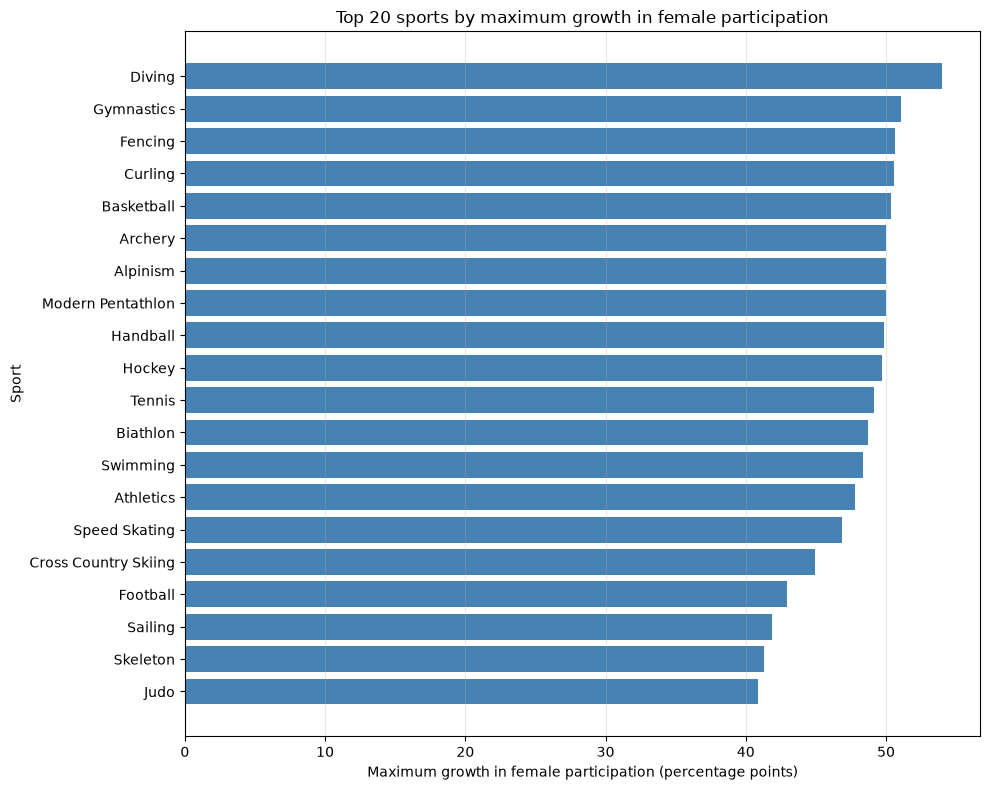

```python
participations = athlete_medals_df.drop_duplicates(
  subset=["ID", "NOC", "Games", "Sport"]
)

yearly = (
  participations
  .groupby(["Sport", "Year"], as_index=False)
  .agg(
    Women=("Sex", lambda s: s.eq("F").sum()),
    Total=("Sex", lambda s: s.isin(["M", "F"]).sum()),
  )
  .assign(Percentage=lambda df: df["Women"] / df["Total"] * 100)
  .sort_values(["Sport", "Year"])
)

first = (
  yearly.groupby("Sport").head(1)
  .set_index("Sport")[["Year", "Women", "Percentage"]]
  .rename(columns={
    "Year": "First_year",
    "Women": "First_women",
    "Percentage": "First_percentage",
  })
)

latest = (
  yearly.groupby("Sport").tail(1)
  .set_index("Sport")[["Year", "Women", "Percentage"]]
  .rename(columns={
    "Year": "Latest_year",
    "Women": "Latest_women",
    "Percentage": "Latest_percentage",
  })
)

record = (
  yearly.loc[yearly.groupby("Sport")["Percentage"].idxmax()]
  .set_index("Sport")[["Year", "Women", "Percentage"]]
  .rename(columns={
    "Year": "Record_year",
    "Women": "Record_women",
    "Percentage": "Record_percentage",
  })
)

games = (
  first.join(latest).join(record)
  .assign(
    Max_growth_pp=lambda df: df["Record_percentage"] - df["First_percentage"],
    Latest_vs_record_pp=lambda df: df["Latest_percentage"] - df["Record_percentage"],
  )
  .sort_values("Max_growth_pp", ascending=False)
  .reset_index()
  .round(2)
)

display(games)

plot_data = games.nlargest(20, "Max_growth_pp").sort_values("Max_growth_pp")

plt.figure(figsize=(10, 8))
plt.barh(plot_data["Sport"], plot_data["Max_growth_pp"], color="steelblue")

plt.xlabel("Maximum growth in female participation (percentage points)")
plt.ylabel("Sport")
plt.title("Top 20 sports by maximum growth in female participation")
plt.grid(axis="x", alpha=0.3)
plt.tight_layout()
plt.show()
```

`top_female_medalists(df, top_n=10)`

Devuelve el Top-N de atletas femeninas con más medallas olímpicas, siguiendo estas reglas de desempate:

1. La atleta con más medallas, contando oros, platas y bronces.
2. Si empatan, por orden alfabético del nombre.

**Parámetros:**

- `df`: DataFrame con los datos de participación y medallas.
- `top_n`: número máximo de atletas que se devolverán. Por defecto, 10.

**Salida:**

Una lista de diccionarios, uno por atleta, con los siguientes campos:

- `id`: identificador de la atleta.
- `name`: nombre de la atleta.
- `number_of_medals`: número total de medallas.
- `medals`: lista de medallas, cada una con su tipo (`Medal`), año (`Year`), deporte (`Sport`) y prueba (`Event`).

Las medallas se ordenan por año, deporte y prueba. Se excluyen las participaciones sin medalla y se eliminan duplicados de una misma atleta, edición, deporte, prueba y tipo de medalla.

```python
def top_female_medalists(df, top_n=10):
  medal_rows = (
    df.loc[
      (df["Sex"] == "F")
      & df["Medal"].isin(["Gold", "Silver", "Bronze"])
    ]
    .drop_duplicates(subset=["ID", "Games", "Sport", "Event", "Medal"])
  )

  athletes = []

  for athlete_id, rows in medal_rows.groupby("ID"):
    athletes.append({
      "id": int(athlete_id),
      "name": rows["Name"].iloc[0],
      "number_of_medals": len(rows),
      "medals": (
        rows.sort_values(["Year", "Sport", "Event"])
        [["Medal", "Year", "Sport", "Event"]]
        .to_dict(orient="records")
      ),
    })

  return sorted(
    athletes,
    key=lambda athlete: (-athlete["number_of_medals"], athlete["name"]),
  )[:top_n]

top_female_medalists(athlete_medals_df)
```

```
[{'id': 67046,
  'name': 'Larysa Semenivna Latynina (Diriy-)',
  'number_of_medals': 18,
  'medals': [{'Medal': 'Gold',
    'Year': 1956,
    'Sport': 'Gymnastics',
    'Event': "Gymnastics Women's Floor Exercise"},
   {'Medal': 'Gold',
    'Year': 1956,
    'Sport': 'Gymnastics',
    'Event': "Gymnastics Women's Horse Vault"},
   {'Medal': 'Gold',
    'Year': 1956,
    'Sport': 'Gymnastics',
    'Event': "Gymnastics Women's Individual All-Around"},
   {'Medal': 'Gold',
    'Year': 1956,
    'Sport': 'Gymnastics',
    'Event': "Gymnastics Women's Team All-Around"},
   {'Medal': 'Bronze',
    'Year': 1956,
    'Sport': 'Gymnastics',
    'Event': "Gymnastics Women's Team Portable Apparatus"},
   {'Medal': 'Silver',
    'Year': 1956,
    'Sport': 'Gymnastics',
    'Event': "Gymnastics Women's Uneven Bars"},
   {'Medal': 'Silver',
    'Year': 1960,
    'Sport': 'Gymnastics',
    'Event': "Gymnastics Women's Balance Beam"},
   {'Medal': 'Gold',
    'Year': 1960,
    'Sport': 'Gymnastics',
    'Event': "Gymnastics Women's Floor Exercise"},
   {'Medal': 'Bronze',
    'Year': 1960,
    'Sport': 'Gymnastics',
    'Event': "Gymnastics Women's Horse Vault"},
   {'Medal': 'Gold',
```

[output cut: 443 more lines]

```
    'Year': 1964,
    'Sport': 'Gymnastics',
    'Event': "Gymnastics Women's Floor Exercise"},
   {'Medal': 'Bronze',
    'Year': 1964,
    'Sport': 'Gymnastics',
    'Event': "Gymnastics Women's Individual All-Around"},
   {'Medal': 'Gold',
    'Year': 1964,
    'Sport': 'Gymnastics',
    'Event': "Gymnastics Women's Team All-Around"},
   {'Medal': 'Gold',
    'Year': 1964,
    'Sport': 'Gymnastics',
    'Event': "Gymnastics Women's Uneven Bars"}]}]
```

**El análisis muestra un aumento progresivo de la participación femenina en los Juegos Olímpicos.** Este crecimiento se ha acelerado especialmente desde la segunda mitad del siglo XX. En los últimos años, las mujeres representan aproximadamente el 45 % en Verano y el 40 % en Invierno. También se observa una incorporación gradual de mujeres a nuevos deportes, especialmente alrededor del año 2000.

Disciplinas como saltos, gimnasia y esgrima destacan por sus grandes incrementos de participación femenina. Esta tendencia, y aunque no se incluya en el dataset, ha ido en aumento hasta 2024, donde tanto hombres como mujeres participaron en una proporción casi idéntica (49% mujeres y 51% hombres)